# Introduction to *Bioconductor*

Juan R Gonzalez (first section of this material is based on Martin Morgan's courses)

# Contents

These are the required libraries to reproduce this document

```r
library(BiocManager)
library(Biobase)
library(Biostrings)
library(snpStats)
library(GenomicRanges)
library(SummarizedExperiment)
library(annotate)
library(hgu95av2.db)
library(org.Hs.eg.db)
library(GO.db)
library(Homo.sapiens)
library(biomaRt)
library(TxDb.Hsapiens.UCSC.hg19.knownGene)
```

# 1 Project Overview

## 1.1 About

[Bioconductor](https://bioconductor.org): Analysis and comprehension of high-throughput genomic data

- Statistical analysis: large data, technological artifacts, designed experiments; rigorous
- Comprehension: biological context, visualization, reproducibility
- High-throughput
  - Sequencing: RNASeq, ChIPSeq, variants, copy number, …
  - Microarrays: expression, SNP, …
  - Flow cytometry, proteomics, images, …

Packages, vignettes, work flows

- 1649 software packages (Jan’19); also…
  - ‘Annotation’ packages – static data bases of identifier maps, gene models, pathways, etc; e.g., TxDb.Hsapiens.UCSC.hg19.knownGene
  - ’Experiment packages – data sets used to illustrate software functionality, e.g., airway
- Discover and navigate via [biocViews](https://bioconductor.org/packages/)
- Package ‘landing page’
  - Title, author / maintainer, short description, citation, installation instructions, …, download statistics
- All user-visible functions have help pages, most with runnable examples
- ‘Vignettes’ an important feature in Bioconductor – narrative documents illustrating how to use the package, with integrated code
- ‘Release’ (every six months) and ‘devel’ branches
- [Support site](https://support.bioconductor.org); [videos](https://www.youtube.com/user/bioconductor), [recent courses](https://bioconductor.org/help/course-materials/)

Package installation and use

- A package needs to be installed once, using the instructions on the package landing page (e.g., DESeq2).

  ```r
  source("https://bioconductor.org/biocLite.R")
  biocLite(c("DESeq2", "org.Hs.eg.db"))
  ```

- **NEW** functions have been created

  ```r
  require(BiocManager)
  install("DESeq2")

  # or

  BiocManager::install("DESeq2")
  ```

older versions can be installed by

````
```r
BiocManager::install("DESeq2", version = "3.8")
```
````

- `biocLite()` and `install()` install *Bioconductor* and [CRAN](https://cran.r-project.org)
- Github packages can be install by

  ```r
  devtools::install_github("isglobal-brge/SNPassoc")
  ```

- Once installed, the package can be loaded into an R session

  ```r
  library(GenomicRanges)
  ```

  and the help system queried interactively, as outlined above:

  ```r
  help(package="GenomicRanges")
  vignette(package="GenomicRanges")
  vignette(package="GenomicRanges", "GenomicRangesHOWTOs")
  ?GRanges
  ```

## 1.2 Key concepts

Goals

- Reproducibility
- Interoperability
- Use

What a few lines of *R* has to say

```r
x <- rnorm(1000)
y <- x + rnorm(1000)
df <- data.frame(X=x, Y=y)
fit <- lm(Y ~ X, df)
anova(fit)
```

```
Analysis of Variance Table

Response: Y
           Df  Sum Sq Mean Sq F value    Pr(>F)
X           1  999.12  999.12   991.4 < 2.2e-16 ***
Residuals 998 1005.76    1.01
---
Signif. codes:  0 '***' 0.001 '**' 0.01 '*' 0.05 '.' 0.1 ' ' 1
```

Classes and methods – “S3”

- `data.frame()`
- Defines *class* to coordinate data
- Creates an *instance* or *object*
- `plot()`, `lm()`, `anova()`, `abline()`: *methods* defined on *generics* to transform instances
- Discovery and help

  ```r
  class(fit)
  methods(class=class(fit))
  methods(plot)
  ?"plot"
  ?"plot.formula"
  ```

- tab completion!

*Bioconductor* classes and methods – “S4”

- Example: working with DNA sequences

  ```r
  require(Biostrings)
  dna <- DNAStringSet(c("AACAT", "GGCGCCT"))
  reverseComplement(dna)
  ```

  ```
    A DNAStringSet instance of length 2
      width seq
  [1]     5 ATGTT
  [2]     7 AGGCGCC
  ```

- Discovery and help

  ```r
  class(dna)
  ?"DNAStringSet-class"
  ?"reverseComplement,DNAStringSet-method"
  ```

## 1.3 High-throughput sequence analysis work flows

1. Experimental design
2. Wet-lab sequence preparation (figure from http://rnaseq.uoregon.edu/)
3. (Illumina) Sequencing (Bentley et al., 2008, doi:10.1038/nature07517)

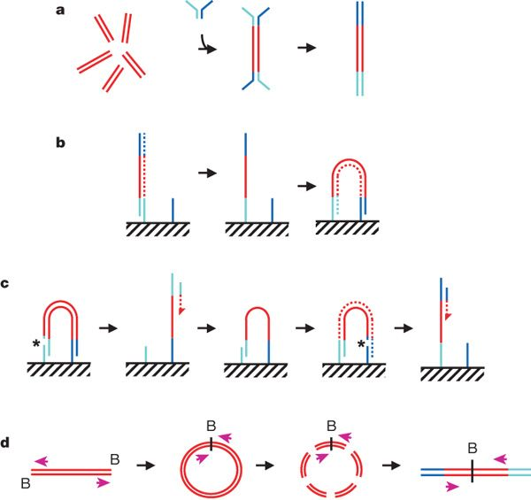

   - Primary output: FASTQ files of short reads and their [quality scores](http://en.wikipedia.org/wiki/FASTQ_format#Encoding)
4. Alignment
   - Choose to match task, e.g., `Rsubread`, Bowtie2 good for ChIPseq, some forms of RNAseq; BWA, GMAP better for variant calling
   - Primary output: BAM files of aligned reads
   - More recently: `kallisto` and similar programs that produce tables of reads aligned to transcripts
5. Reduction
   - e.g., RNASeq ‘count table’ (simple spreadsheets), DNASeq called variants (VCF files), ChIPSeq peaks (BED, WIG files)
6. Analysis
   - Differential expression, peak identification, …
7. Comprehension
   - Biological context

## 1.4 *Bioconductor* sequencing ecosystem

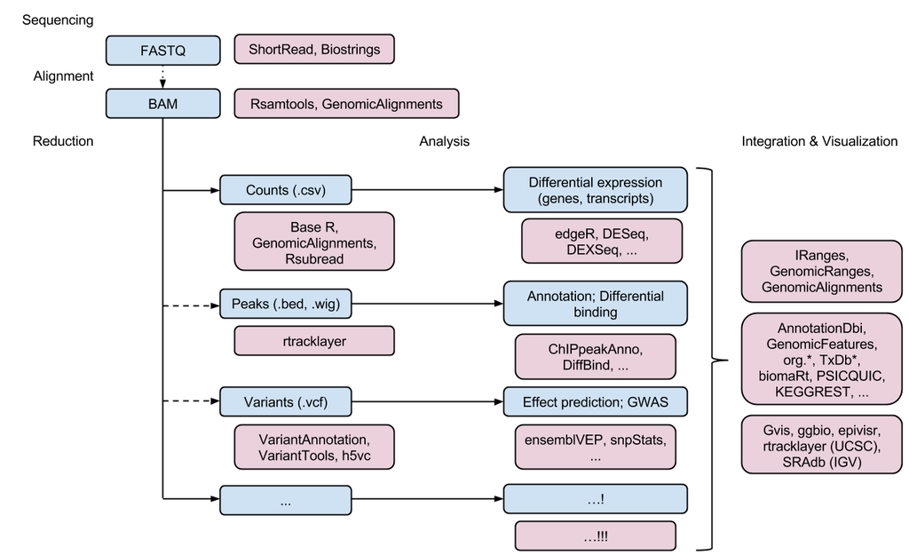

Alt Ecosystem

# 2 Annotation

## 2.1 `annotate` package

Bioconductor distributes annotation packages for a wide range of gene expression microarrays and RNA-seq data. The annotate package is one way to use this annotation information. This code loads the `annotate` package and the databases for the Gene Ontology and one of the Affymetrix human microarray chips.

```r
require(annotate)
require(hgu95av2.db)
require(GO.db)
```

The databases are queried with `get()` or `mget()` for multiple queries:

```r
get("32972_at", envir=hgu95av2GENENAME)
```

```
[1] "NADPH oxidase 1"
```

```r
mget(c("738_at", "40840_at", "32972_at"),
     envir=hgu95av2GENENAME)
```

```
$`738_at`
[1] "5'-nucleotidase, cytosolic II"

$`40840_at`
[1] "peptidylprolyl isomerase F"

$`32972_at`
[1] "NADPH oxidase 1"
```

The name of the availabe information in a Bioconductor database (ended by `.db`, for instance `org.Hs.eg.db`) can be retreived by using `columns()`:

```r
columns(hgu95av2.db)
```

```
 [1] "ACCNUM"       "ALIAS"        "ENSEMBL"      "ENSEMBLPROT"  "ENSEMBLTRANS" "ENTREZID"
 [7] "ENZYME"       "EVIDENCE"     "EVIDENCEALL"  "GENENAME"     "GO"           "GOALL"
[13] "IPI"          "MAP"          "OMIM"         "ONTOLOGY"     "ONTOLOGYALL"  "PATH"
[19] "PFAM"         "PMID"         "PROBEID"      "PROSITE"      "REFSEQ"       "SYMBOL"
[25] "UCSCKG"       "UNIGENE"      "UNIPROT"
```

The GO terms can be managed by

```r
go <- get("738_at", envir=hgu95av2GO)
names(go)
```

```
 [1] "GO:0006195" "GO:0016310" "GO:0016311" "GO:0017144" "GO:0046040" "GO:0046085" "GO:0005829"
 [8] "GO:0000166" "GO:0005515" "GO:0008253" "GO:0008253" "GO:0046872" "GO:0050146"
```

```r
get("GO:0009117", envir=GOTERM)
```

```
GOID: GO:0009117
Term: nucleotide metabolic process
Ontology: BP
Definition: The chemical reactions and pathways involving a nucleotide, a nucleoside that
    is esterified with (ortho)phosphate or an oligophosphate at any hydroxyl group on the
    glycose moiety; may be mono-, di- or triphosphate; this definition includes cyclic
    nucleotides (nucleoside cyclic phosphates).
Synonym: nucleotide metabolism
```

There are multiple annotated databases in Bioconductor that can be found here: [annotated data bases](http://bioconductor.org/packages/release/data/annotation/). For example

```r
require(org.Hs.eg.db)
columns(org.Hs.eg.db)
```

```
 [1] "ACCNUM"       "ALIAS"        "ENSEMBL"      "ENSEMBLPROT"  "ENSEMBLTRANS" "ENTREZID"
 [7] "ENZYME"       "EVIDENCE"     "EVIDENCEALL"  "GENENAME"     "GO"           "GOALL"
[13] "IPI"          "MAP"          "OMIM"         "ONTOLOGY"     "ONTOLOGYALL"  "PATH"
[19] "PFAM"         "PMID"         "PROSITE"      "REFSEQ"       "SYMBOL"       "UCSCKG"
[25] "UNIGENE"      "UNIPROT"
```

```r
# get the gene symbol
get("9726", envir=org.Hs.egSYMBOL)
```

```
[1] "ZNF646"
```

## 2.2 BioMart

[BioMart](http://www.biomart.org) is a query-oriented data management system developed jointly by the European Bioinformatics Institute (EBI) and Cold Spring Harbor Laboratory (CSHL).

`biomaRt` is an R interface to BioMart systems, in particular to Ensembl. Ensembl is a joint project between EMBL - European Bioinformatics Institute (EBI) and the Wellcome Trust Sanger Institute (WTSI) to develop a software system which produces and maintains automatic annotation on selected eukaryotic genomes. There are several databases that can be queried:

```r
require(biomaRt)
head(listMarts())
```

```
               biomart               version
1 ENSEMBL_MART_ENSEMBL      Ensembl Genes 95
2   ENSEMBL_MART_MOUSE      Mouse strains 95
3     ENSEMBL_MART_SNP  Ensembl Variation 95
4 ENSEMBL_MART_FUNCGEN Ensembl Regulation 95
```

After selecting a database (e.g., **ensembl**) we select a dataset:

```r
mart <- useMart(biomart="ensembl")
listDatasets(mart)[1:10,]
```

```
                       dataset                              description                version
1     acalliptera_gene_ensembl         Eastern happy genes (fAstCal1.2)             fAstCal1.2
2   acarolinensis_gene_ensembl           Anole lizard genes (AnoCar2.0)              AnoCar2.0
3    acitrinellus_gene_ensembl           Midas cichlid genes (Midas_v5)               Midas_v5
4    amelanoleuca_gene_ensembl                    Panda genes (ailMel1)                ailMel1
5      amexicanus_gene_ensembl Cave fish genes (Astyanax_mexicanus-2.0) Astyanax_mexicanus-2.0
6      anancymaae_gene_ensembl       Ma's night monkey genes (Anan_2.0)               Anan_2.0
7      aocellaris_gene_ensembl      Clown anemonefish genes (AmpOce1.0)              AmpOce1.0
8        apercula_gene_ensembl         Orange clownfish genes (Nemo_v1)                Nemo_v1
9  aplatyrhynchos_gene_ensembl                Duck genes (BGI_duck_1.0)           BGI_duck_1.0
10  apolyacanthus_gene_ensembl        Spiny chromis genes (ASM210954v1)            ASM210954v1
```

After selecting a dataset (e.g., **hsapiens_gene_ensembl**) we select the attributes we are interested in:

```r
mart  <- useMart(biomart="ensembl",
                 dataset="hsapiens_gene_ensembl")
listAttributes(mart)[1:10,]
```

```
                            name                  description         page
1                ensembl_gene_id               Gene stable ID feature_page
2        ensembl_gene_id_version       Gene stable ID version feature_page
3          ensembl_transcript_id         Transcript stable ID feature_page
4  ensembl_transcript_id_version Transcript stable ID version feature_page
5             ensembl_peptide_id            Protein stable ID feature_page
6     ensembl_peptide_id_version    Protein stable ID version feature_page
7                ensembl_exon_id               Exon stable ID feature_page
8                    description             Gene description feature_page
9                chromosome_name     Chromosome/scaffold name feature_page
10                start_position              Gene start (bp) feature_page
```

**NOTE**: sometimes the host is not working. If so, try host=“www.ensembl.org” in the `useMart` function.

After selecting the dataset we can make different types of queries:

- **Query 1**: We could look for all the transcripts contained in the gene `7791` (entrez id):

```r
tx <- getBM(attributes="ensembl_transcript_id",
            filters="entrezgene",
            values="7791", mart=mart)
tx
```

```
   ensembl_transcript_id
1        ENST00000322764
2        ENST00000449630
3        ENST00000468083
4        ENST00000457235
5        ENST00000354434
6        ENST00000392910
7        ENST00000477373
8        ENST00000436448
9        ENST00000446634
10       ENST00000497119
11       ENST00000646695
12       ENST00000647126
13       ENST00000644791
14       ENST00000642783
15       ENST00000643962
16       ENST00000645637
17       ENST00000645428
18       ENST00000644767
19       ENST00000647142
20       ENST00000644808
```

- *Query 2*: We could look for chromosome, position and gene name of a list of genes (entrez id):

```r
genes <- c("79699", "7791", "23140", "26009")
tx <- getBM(attributes=c("chromosome_name", "start_position",
                         "hgnc_symbol"),
            filters="entrezgene",
            values=genes, mart=mart)
tx
```

```
  chromosome_name start_position hgnc_symbol
1              17        4004445       ZZEF1
2               1       77562416
3               7      143381080         ZYX
4 CHR_HG708_PATCH      143381080         ZYX
5               1       52726467      ZYG11B
```

- **Query 3**: We could look for chromosome, position and gene name of a list of genes (ENSEMBL):

```r
genes <- c("ENSG00000074755")
tx <- getBM(attributes=c("chromosome_name", "start_position",
                         "hgnc_symbol"),
            filters="ensembl_gene_id",
            values=genes, mart=mart)
tx
```

```
  chromosome_name start_position hgnc_symbol
1              17        4004445       ZZEF1
```

- **Query 4**: Homology. `getLDS()` combines two data marts, for example to homologous genes in other species. We can look up the mouse equivalents of a particular Affy transcript, or of the NOX1 gene.

```r
human <- useMart("ensembl", dataset = "hsapiens_gene_ensembl")
mouse <- useMart("ensembl", dataset = "mmusculus_gene_ensembl")
getLDS(attributes = c("hgnc_symbol","chromosome_name",
       "start_position"),
       filters = "hgnc_symbol", values = "NOX1",
       mart = human,
       attributesL = c("external_gene_name", "chromosome_name",
       "start_position"),
       martL = mouse)
```

```
  HGNC.symbol Chromosome.scaffold.name Gene.start..bp. Gene.name Chromosome.scaffold.name.1
1        NOX1                        X       100843324      Nox1                          X
  Gene.start..bp..1
1         134086421
```

## 2.3 Annotate SNPs

We had a set of 100 SNPs without chromosome and genomic position information. We need to know the gene that those SNPs belong to.

```r
load("data/snpsList.Rdata")
length(snpsList)
```

```
[1] 100
```

```r
head(snpsList)
```

```
[1] "rs1932919"  "rs6849766"  "rs11246756" "rs7184849"  "rs308857"   "rs16990309"
```

- A hand-search (Genome Browser - ) would be easy but tedious, so we want an automated approach.
- `R` can be used to carry out the entire analysis. That is, GWAS, annotation and post-GWAS. The annotation can be set by connecting `R` with Biomart:

```r
snpmart <- useMart("ENSEMBL_MART_SNP", dataset = "hsapiens_snp")
```

- Use `listAttributes()` to get valid attribute names.
- Use `listFilters()` to get valid filter names.

```r
head(listAttributes(snpmart))
```

```
                       name                             description page
1                 refsnp_id                            Variant name  snp
2             refsnp_source                          Variant source  snp
3 refsnp_source_description              Variant source description  snp
4                  chr_name                Chromosome/scaffold name  snp
5               chrom_start Chromosome/scaffold position start (bp)  snp
6                 chrom_end   Chromosome/scaffold position end (bp)  snp
```

```r
head(listFilters(snpmart))
```

```
          name              description
1     chr_name Chromosome/scaffold name
2        start                    Start
3          end                      End
4   band_start               Band Start
5     band_end                 Band End
6 marker_start             Marker Start
```

We can retrieve chromosome name, genomic position and reference allele in 1000 Genome Project of the ‘significant SNPs’ (provided in out list) by:

```r
snpInfo <- getBM(c("refsnp_id", "chr_name", "chrom_start",
                   "allele"), filters = c("snp_filter"),
                 values = snpsList, mart = snpmart)
head(snpInfo)
```

```
   refsnp_id chr_name chrom_start allele
1   rs419655        1    24986471  T/A/C
2 rs11206019        1    52794278    G/T
3 rs10788998        1    55233350    G/A
4  rs3748543        1    61130317    C/T
5   rs485141        1    76618179  C/A/G
6   rs680017        1    99202181    A/G
```

```r
snpInfo$chr_name <- paste0("chr", snpInfo$chr_name)
```

How do we annotate this SNPs into genes?

- Fist, transform SNP annotation into a `GenomicRange`

```r
snpsInfo.gr <- makeGRangesFromDataFrame(snpInfo,
                                        start.field="chrom_start",
                                        keep.extra.columns = TRUE,
                                        seqnames.field = "chr_name",
                                        end.field = "chrom_start")
snpsInfo.gr
```

```
GRanges object with 102 ranges and 2 metadata columns:
                       seqnames    ranges strand |   refsnp_id      allele
                          <Rle> <IRanges>  <Rle> | <character> <character>
    [1]                    chr1  24986471      * |    rs419655       T/A/C
    [2]                    chr1  52794278      * |  rs11206019         G/T
    [3]                    chr1  55233350      * |  rs10788998         G/A
    [4]                    chr1  61130317      * |   rs3748543         C/T
    [5]                    chr1  76618179      * |    rs485141       C/A/G
    ...                     ...       ...    ... .         ...         ...
   [98] chrCHR_HSCHR1_3_CTG32_1 243722546      * |   rs2125230         G/A
   [99]   chrCHR_HSCHR22_1_CTG6  23451614      * |   rs5751670         C/T
  [100]                    chrX  64333971      * |   rs1932919         C/T
  [101]                    chrX 101998212      * |   rs5944928         C/T
  [102]                    chrX 151640975      * |  rs12861395       A/G/T
  -------
  seqinfo: 25 sequences from an unspecified genome; no seqlengths
```

# 3 Handling Omic Data

## 3.1 SNP array data

snpStats (former [snpMatrix](http://www.bioconductor.org/packages//2.7/bioc/html/snpMatrix.html))

- FAM file: one row per individual - identification information: Family ID, Individual ID Paternal ID, Maternal ID, Sex (1=male; 2=female; other=unknown), Phenotype.
- BIM file: one row per SNP (rs id, chromosome, position, allele 1, allele 2).
- BED file: one row per individual. Genotypes in columns.

Data are easily loaded into R by using `read.plink` function

```r
require(snpStats)
snps <- read.plink("data/obesity") # there are three files obesity.fam, obesity.bim, obesity.bed
names(snps)
```

```
[1] "genotypes" "fam"       "map"
```

Genotypes is a `snpMatrix` object

```r
geno <- snps$genotypes
geno
```

```
A SnpMatrix with  2312 rows and  100000 columns
Row names:  100 ... 998
Col names:  MitoC3993T ... rs28600179
```

Annotation is a `data.frame` object

```r
annotation <- snps$map
head(annotation)
```

```
           chromosome   snp.name cM position allele.1 allele.2
MitoC3993T         NA MitoC3993T NA     3993        T        C
MitoG4821A         NA MitoG4821A NA     4821        A        G
MitoG6027A         NA MitoG6027A NA     6027        A        G
MitoT6153C         NA MitoT6153C NA     6153        C        T
MitoC7275T         NA MitoC7275T NA     7275        T        C
MitoT9699C         NA MitoT9699C NA     9699        C        T
```

## 3.2 ExpressionSet

ExpressionSet

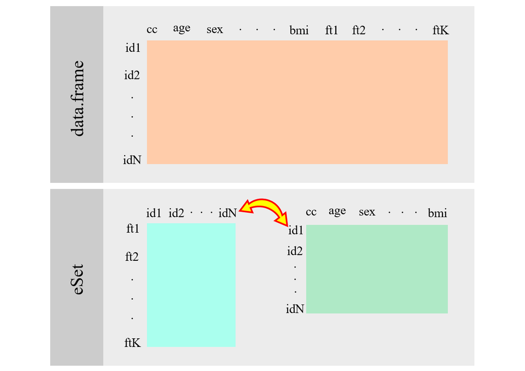

Alt ExpressionSet

Description

- `Biobase` is part of the Bioconductor project and contains standardized data structures to represent genomic data.
- The `ExpressionSet` class is designed to combine several different sources of information into a single convenient structure.
- An `ExpressionSet` can be manipulated (e.g., subsetted, copied) conveniently, and is the input or output from many Bioconductor functions.
- The data in an `ExpressionSet` consists of expression data from microarray experiments, `meta-data’ describing samples in the experiment, annotations and meta-data about the features on the chip and information related to the protocol used for processing each sample
- Print

```r
library(tweeDEseqCountData)
data(pickrell)
pickrell.eset
```

```
ExpressionSet (storageMode: lockedEnvironment)
assayData: 52580 features, 69 samples
  element names: exprs
protocolData: none
phenoData
  sampleNames: NA18486 NA18498 ... NA19257 (69 total)
  varLabels: num.tech.reps population study gender
  varMetadata: labelDescription
featureData
  featureNames: ENSG00000000003 ENSG00000000005 ... LRG_99 (52580 total)
  fvarLabels: gene
  fvarMetadata: labelDescription
experimentData: use 'experimentData(object)'
Annotation:
```

- Get experimental data (e.g., gene expression)

```r
genes <- exprs(pickrell.eset)
genes[1:4,1:4]
```

```
                NA18486 NA18498 NA18499 NA18501
ENSG00000000003       0       0       0       0
ENSG00000000005       0       0       0       0
ENSG00000000419      22     105      40      55
ENSG00000000457      22     100     107      53
```

Get phenotypic data (e.g. covariates, disease status, outcomes, …)

```r
pheno <- pData(pickrell.eset)
head(pheno)
```

```
        num.tech.reps population    study gender
NA18486             2        YRI Pickrell   male
NA18498             2        YRI Pickrell   male
NA18499             2        YRI Pickrell female
NA18501             2        YRI Pickrell   male
NA18502             2        YRI Pickrell female
NA18504             2        YRI Pickrell   male
```

```r
pheno$gender
```

```
 [1] male   male   female male   female male   female male   female male   female male   female
[14] male   female male   female female male   female male   female female male   female male
[27] female female male   female female male   female male   female female female female male
[40] female male   male   female female male   female female male   female female male   female
[53] male   male   female female male   female male   female male   female female male   female
[66] female female male   female
Levels: female male
```

This also works

```r
pickrell.eset$gender
```

```
 [1] male   male   female male   female male   female male   female male   female male   female
[14] male   female male   female female male   female male   female female male   female male
[27] female female male   female female male   female male   female female female female male
[40] female male   male   female female male   female female male   female female male   female
[53] male   male   female female male   female male   female male   female female male   female
[66] female female male   female
Levels: female male
```

Subsetting (everything is synchronized)

```r
eSet.male <- pickrell.eset[, pickrell.eset$gender=="male"]
eSet.male
```

```
ExpressionSet (storageMode: lockedEnvironment)
assayData: 52580 features, 29 samples
  element names: exprs
protocolData: none
phenoData
  sampleNames: NA18486 NA18498 ... NA19239 (29 total)
  varLabels: num.tech.reps population study gender
  varMetadata: labelDescription
featureData
  featureNames: ENSG00000000003 ENSG00000000005 ... LRG_99 (52580 total)
  fvarLabels: gene
  fvarMetadata: labelDescription
experimentData: use 'experimentData(object)'
Annotation:
```

Finally, the `fData` function gets the probes’ annotation in a `data.frame`. Let us first illustrate how to provide an annotation to an `ExpressionSet` object

```r
require(Homo.sapiens)
geneSymbols <- rownames(genes)
annot <- select(Homo.sapiens, geneSymbols,
                columns=c("TXCHROM", "SYMBOL"), keytype="ENSEMBL")
annotation(pickrell.eset) <- "Homo.sapiens"
fData(pickrell.eset) <- annot
pickrell.eset
```

```
ExpressionSet (storageMode: lockedEnvironment)
assayData: 52580 features, 69 samples
  element names: exprs
protocolData: none
phenoData
  sampleNames: NA18486 NA18498 ... NA19257 (69 total)
  varLabels: num.tech.reps population study gender
  varMetadata: labelDescription
featureData
  featureNames: 1 2 ... 59373 (59373 total)
  fvarLabels: ENSEMBL SYMBOL TXCHROM
  fvarMetadata: labelDescription
experimentData: use 'experimentData(object)'
Annotation: Homo.sapiens
```

```r
probes <- fData(pickrell.eset)
head(probes)
```

```
          ENSEMBL   SYMBOL TXCHROM
1 ENSG00000000003   TSPAN6    chrX
2 ENSG00000000005     TNMD    chrX
3 ENSG00000000419     DPM1   chr20
4 ENSG00000000457    SCYL3    chr1
5 ENSG00000000460 C1orf112    chr1
6 ENSG00000000938      FGR    chr1
```

## 3.3 Genomic ranges

GenomicRanges

- `GRanges()`: genomic coordinates to represent annotations (exons, genes, regulatory marks, …) and data (called peaks, variants, aligned reads)
- `GRangesList()`: genomic coordinates grouped into list elements (e.g., paired-end reads; exons grouped by transcript)

Operations

- intra-range: act on each range independently
  - e.g., `shift()`
- inter-range: act on all ranges in a `GRanges` object or `GRangesList` element
  - e.g., `reduce()`; `disjoin()`
- between-range: act on two separate `GRanges` or `GRangesList` objects
  - e.g., `findOverlaps()`, `nearest()`

```r
require(GenomicRanges)
gr <- GRanges("chr1", IRanges(c(10, 20, 22), width=5), "+")
gr
```

```
GRanges object with 3 ranges and 0 metadata columns:
      seqnames    ranges strand
         <Rle> <IRanges>  <Rle>
  [1]     chr1     10-14      +
  [2]     chr1     20-24      +
  [3]     chr1     22-26      +
  -------
  seqinfo: 1 sequence from an unspecified genome; no seqlengths
```

```r
# shift move all intervals 3 base pair towards the end
shift(gr, 3)
```

```
GRanges object with 3 ranges and 0 metadata columns:
      seqnames    ranges strand
         <Rle> <IRanges>  <Rle>
  [1]     chr1     13-17      +
  [2]     chr1     23-27      +
  [3]     chr1     25-29      +
  -------
  seqinfo: 1 sequence from an unspecified genome; no seqlengths
```

```r
# inter-range
range(gr)
```

```
GRanges object with 1 range and 0 metadata columns:
      seqnames    ranges strand
         <Rle> <IRanges>  <Rle>
  [1]     chr1     10-26      +
  -------
  seqinfo: 1 sequence from an unspecified genome; no seqlengths
```

```r
# creates the smallest range set of unique, non-overlapping intervals
reduce(gr)
```

```
GRanges object with 2 ranges and 0 metadata columns:
      seqnames    ranges strand
         <Rle> <IRanges>  <Rle>
  [1]     chr1     10-14      +
  [2]     chr1     20-26      +
  -------
  seqinfo: 1 sequence from an unspecified genome; no seqlengths
```

```r
# two Granges: knowing the intervals that overlap with a targeted region
snps <- GRanges("chr1", IRanges(c(11, 17), width=1))
snps
```

```
GRanges object with 2 ranges and 0 metadata columns:
      seqnames    ranges strand
         <Rle> <IRanges>  <Rle>
  [1]     chr1        11      *
  [2]     chr1        17      *
  -------
  seqinfo: 1 sequence from an unspecified genome; no seqlengths
```

```r
gr.ov <- findOverlaps(snps, gr)
gr.ov
```

```
Hits object with 1 hit and 0 metadata columns:
      queryHits subjectHits
      <integer>   <integer>
  [1]         1           1
  -------
  queryLength: 2 / subjectLength: 3
```

```r
# recover the overlapping intervals
gr[subjectHits(gr.ov)]
```

```
GRanges object with 1 range and 0 metadata columns:
      seqnames    ranges strand
         <Rle> <IRanges>  <Rle>
  [1]     chr1     10-14      +
  -------
  seqinfo: 1 sequence from an unspecified genome; no seqlengths
```

```r
#coverage: summarizes the times each base is covered by an interval
coverage(gr)
```

```
RleList of length 1
$chr1
integer-Rle of length 26 with 6 runs
  Lengths: 9 5 5 2 3 2
  Values : 0 1 0 1 2 1
```

```r
# get counts
countOverlaps(gr, snps)
```

```
[1] 1 0 0
```

## 3.4 Summarized experiments

SummarizedExperiment:

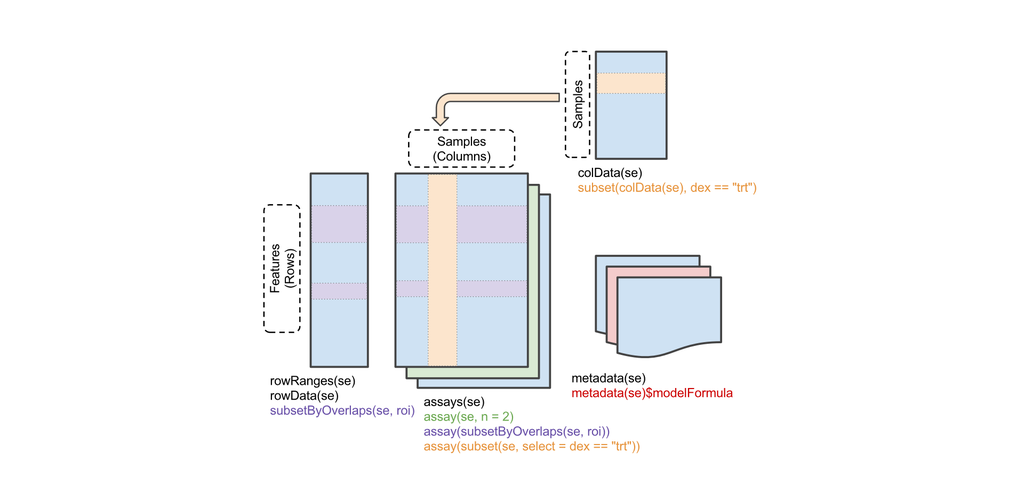

Alt SummarizedExperiment

- Comprehensive data structure that can be used to store expression and methylation data from microarrays or read counts from RNA-seq experiments, among others.
- Can contain slots for one or more *omic* datasets, feature annotation (e.g. genes, transcripts, SNPs, CpGs), individual phenotypes and experimental details, such as laboratory and experimental protocols.
- As in an `ExpressionSet` a `SummarizedExperiment`, the rows of *omic* data are features and columns are subjects.
- Coordinate feature x sample ‘assays’ with row (feature) and column (sample) descriptions.
- ‘assays’ (similar to ‘exprs’ in `ExpressionSet`objects) can be any matrix-like object, including very large on-disk representations such as HDF5Array
- ‘assays’ are annotated using `GenomicRanges`
- It is being deprecated

## 3.5 RangedSummarizedExperiments

`SummarizedExperiment` is extended to `RangedSummarizedExperiment`, a child class that contains the annotation data of the features in a `GenomicRanges` object. An example dataset, stored as a `RangedSummarizedExperiment` is available in the `airway` package. This data represents an RNA sequencing experiment.

```r
library(airway)
data(airway)
airway
```

```
class: RangedSummarizedExperiment
dim: 64102 8
metadata(1): ''
assays(1): counts
rownames(64102): ENSG00000000003 ENSG00000000005 ... LRG_98 LRG_99
rowData names(0):
colnames(8): SRR1039508 SRR1039509 ... SRR1039520 SRR1039521
colData names(9): SampleName cell ... Sample BioSample
```

- Some aspects of the object are very similar to `ExpressionSet`, although with slightly different names and types. `colData` contains phenotype (sample) information, like `pData` for `ExpressionSet`. It returns a `DataFrame` instead of a data.frame:

```r
colData(airway)
```

```
DataFrame with 8 rows and 9 columns
           SampleName     cell      dex    albut        Run avgLength Experiment    Sample
             <factor> <factor> <factor> <factor>   <factor> <integer>   <factor>  <factor>
SRR1039508 GSM1275862   N61311    untrt    untrt SRR1039508       126  SRX384345 SRS508568
SRR1039509 GSM1275863   N61311      trt    untrt SRR1039509       126  SRX384346 SRS508567
SRR1039512 GSM1275866  N052611    untrt    untrt SRR1039512       126  SRX384349 SRS508571
SRR1039513 GSM1275867  N052611      trt    untrt SRR1039513        87  SRX384350 SRS508572
SRR1039516 GSM1275870  N080611    untrt    untrt SRR1039516       120  SRX384353 SRS508575
SRR1039517 GSM1275871  N080611      trt    untrt SRR1039517       126  SRX384354 SRS508576
SRR1039520 GSM1275874  N061011    untrt    untrt SRR1039520       101  SRX384357 SRS508579
SRR1039521 GSM1275875  N061011      trt    untrt SRR1039521        98  SRX384358 SRS508580
              BioSample
               <factor>
SRR1039508 SAMN02422669
SRR1039509 SAMN02422675
SRR1039512 SAMN02422678
SRR1039513 SAMN02422670
SRR1039516 SAMN02422682
SRR1039517 SAMN02422673
SRR1039520 SAMN02422683
SRR1039521 SAMN02422677
```

- You can still use `$` to get a particular column:

```r
airway$cell
```

```
[1] N61311  N61311  N052611 N052611 N080611 N080611 N061011 N061011
Levels: N052611 N061011 N080611 N61311
```

- The measurement data are accessed by `assay` and `assays`. A `SummarizedExperiment` can contain multiple measurement matrices (all of the same dimension). You get all of them by assays and you select a particular one by `assay(OBJECT, NAME)` where you can see the names when you print the object or by using `assayNames`. In this case there is a single matrix called counts:

```r
assayNames(airway)
```

```
[1] "counts"
```

```r
assays(airway)
```

```
List of length 1
names(1): counts
```

```r
head(assay(airway, "counts"))
```

```
                SRR1039508 SRR1039509 SRR1039512 SRR1039513 SRR1039516 SRR1039517 SRR1039520
ENSG00000000003        679        448        873        408       1138       1047        770
ENSG00000000005          0          0          0          0          0          0          0
ENSG00000000419        467        515        621        365        587        799        417
ENSG00000000457        260        211        263        164        245        331        233
ENSG00000000460         60         55         40         35         78         63         76
ENSG00000000938          0          0          2          0          1          0          0
                SRR1039521
ENSG00000000003        572
ENSG00000000005          0
ENSG00000000419        508
ENSG00000000457        229
ENSG00000000460         60
ENSG00000000938          0
```

- Annotation is a `GenomicRanges` object

```r
rowRanges(airway)
```

```
GRangesList object of length 64102:
$ENSG00000000003
GRanges object with 17 ranges and 2 metadata columns:
       seqnames            ranges strand |   exon_id       exon_name
          <Rle>         <IRanges>  <Rle> | <integer>     <character>
   [1]        X 99883667-99884983      - |    667145 ENSE00001459322
   [2]        X 99885756-99885863      - |    667146 ENSE00000868868
   [3]        X 99887482-99887565      - |    667147 ENSE00000401072
   [4]        X 99887538-99887565      - |    667148 ENSE00001849132
   [5]        X 99888402-99888536      - |    667149 ENSE00003554016
   ...      ...               ...    ... .       ...             ...
  [13]        X 99890555-99890743      - |    667156 ENSE00003512331
  [14]        X 99891188-99891686      - |    667158 ENSE00001886883
  [15]        X 99891605-99891803      - |    667159 ENSE00001855382
  [16]        X 99891790-99892101      - |    667160 ENSE00001863395
  [17]        X 99894942-99894988      - |    667161 ENSE00001828996

...
<64101 more elements>
-------
seqinfo: 722 sequences (1 circular) from an unspecified genome
```

- Subset for only rows (e.g. features) which are in the interval 1 to 1Mb of chromosome 1

```r
roi <- GRanges(seqnames="1", ranges=IRanges(start=1, end=1e6))
subsetByOverlaps(airway, roi)
```

```
class: RangedSummarizedExperiment
dim: 79 8
metadata(1): ''
assays(1): counts
rownames(79): ENSG00000177757 ENSG00000185097 ... ENSG00000272512 ENSG00000273443
rowData names(0):
colnames(8): SRR1039508 SRR1039509 ... SRR1039520 SRR1039521
colData names(9): SampleName cell ... Sample BioSample
```

## 3.6 MultiDataSet

MultiDataSet

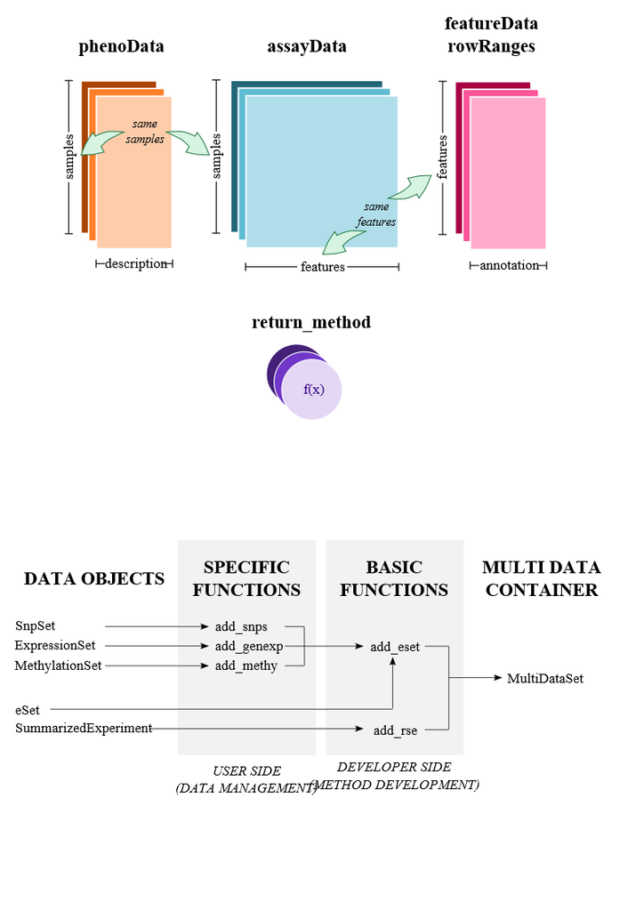

Alt MultiDataSet

- Designed to encapsulate different types of datasets (including all classes in Bioconductor)
- It properly deals with non-complete cases situations
- Subsetting is easily performed in both: samples and features (using GenomicRanges)
- It allows to: – perform integration analysis with third party packages; – create new methods and functions for omic data integration; – encapsule new unimplemented data from any biological experiment
- MultiAssayExperiment is another infrastructure (created by BioC developers)